# Capstone Quiz I

Complete all **Exercises**, and submit answers to **Questions** on the Coursera platform.

This initial quiz will concern exploratory data analysis (EDA) of the Ames Housing dataset. EDA is essential when working with any source of data and helps inform modeling.

First, let us load the data:

```r
load("ames_train.Rdata")
```

Let’s also load some useful libraries

```r
library(statsr)
library(dplyr)
library(ggplot2)
library(gridExtra)
library(statsr)
```

1. Which of the following are the three variables with the highest number of missing observations?
   1. `Misc.Feature`, `Fence`, `Pool.QC`
   2. `Misc.Feature`, `Alley`, `Pool.QC`
   3. `Pool.QC`, `Alley`, `Fence`
   4. `Fireplace.Qu`, `Pool.QC`, `Lot.Frontage`

**Answer**: 2. `Misc.Feature`, `Alley`, `Pool.QC`

```r
# type your code for Question 1 here, and Knit
summary(ames_train[, c("Misc.Feature", 'Fence', 'Alley', 'Pool.QC', 'Lot.Frontage',
                       "Fireplace.Qu")])
```

```
##  Misc.Feature   Fence      Alley     Pool.QC     Lot.Frontage    Fireplace.Qu
##  Elev:  0     GdPrv: 43   Grvl: 33   Ex  :  1   Min.   : 21.00   Ex  : 16
##  Gar2:  2     GdWo : 37   Pave: 34   Fa  :  1   1st Qu.: 57.00   Fa  : 24
##  Othr:  1     MnPrv:120   NA's:933   Gd  :  1   Median : 69.00   Gd  :232
##  Shed: 25     MnWw :  2              TA  :  0   Mean   : 69.21   Po  : 18
##  TenC:  1     NA's :798              NA's:997   3rd Qu.: 80.00   TA  :219
##  NA's:971                                       Max.   :313.00   NA's:491
##                                                 NA's   :167
```

2. How many categorical variables are coded in R as having type `int`? Change them to factors when conducting your analysis.
   1. 0
   2. 1
   3. 2
   4. 3

**Answer**: 3. There are 2

```r
ames_train %>% select(where(is.numeric)) %>% str()
```

```
## tibble [1,000 × 38] (S3: tbl_df/tbl/data.frame)
##  $ PID            : int [1:1000] 909176150 905476230 911128020 535377150 534177230 908128060 902135020 528228540 923426010 908186050 ...
##  $ area           : int [1:1000] 856 1049 1001 1039 1665 1922 936 1246 889 1072 ...
##  $ price          : int [1:1000] 126000 139500 124900 114000 227000 198500 93000 187687 137500 140000 ...
##  $ MS.SubClass    : int [1:1000] 30 120 30 70 60 85 20 20 20 180 ...
##  $ Lot.Frontage   : int [1:1000] NA 42 60 80 70 64 60 53 74 35 ...
##  $ Lot.Area       : int [1:1000] 7890 4235 6060 8146 8400 7301 6000 3710 12395 3675 ...
##  $ Overall.Qual   : int [1:1000] 6 5 5 4 8 7 4 7 5 6 ...
##  $ Overall.Cond   : int [1:1000] 6 5 9 8 6 5 4 5 6 5 ...
##  $ Year.Built     : int [1:1000] 1939 1984 1930 1900 2001 2003 1953 2007 1984 2005 ...
##  $ Year.Remod.Add : int [1:1000] 1950 1984 2007 2003 2001 2003 1953 2008 1984 2005 ...
##  $ Mas.Vnr.Area   : int [1:1000] 0 149 0 0 0 500 0 20 0 76 ...
##  $ BsmtFin.SF.1   : int [1:1000] 238 552 737 0 643 0 0 0 647 467 ...
##  $ BsmtFin.SF.2   : int [1:1000] 0 393 0 0 0 0 0 0 0 0 ...
##  $ Bsmt.Unf.SF    : int [1:1000] 618 104 100 405 167 0 936 1146 217 80 ...
```

[output cut: 24 more lines]

Now let’s take a look to the value range of this int variables. If the range is somehow limited, there might be classified as factors.

```r
ames_train %>% select(where(is.numeric)) %>% summary()
```

```
##       PID                 area          price         MS.SubClass
##  Min.   :5.263e+08   Min.   : 334   Min.   : 12789   Min.   : 20.00
##  1st Qu.:5.285e+08   1st Qu.:1092   1st Qu.:129762   1st Qu.: 20.00
##  Median :5.354e+08   Median :1411   Median :159467   Median : 50.00
##  Mean   :7.059e+08   Mean   :1477   Mean   :181190   Mean   : 57.15
##  3rd Qu.:9.071e+08   3rd Qu.:1743   3rd Qu.:213000   3rd Qu.: 70.00
##  Max.   :1.007e+09   Max.   :4676   Max.   :615000   Max.   :190.00
##
##   Lot.Frontage       Lot.Area       Overall.Qual     Overall.Cond
##  Min.   : 21.00   Min.   :  1470   Min.   : 1.000   Min.   :1.000
##  1st Qu.: 57.00   1st Qu.:  7314   1st Qu.: 5.000   1st Qu.:5.000
##  Median : 69.00   Median :  9317   Median : 6.000   Median :5.000
##  Mean   : 69.21   Mean   : 10352   Mean   : 6.095   Mean   :5.559
##  3rd Qu.: 80.00   3rd Qu.: 11650   3rd Qu.: 7.000   3rd Qu.:6.000
##  Max.   :313.00   Max.   :215245   Max.   :10.000   Max.   :9.000
##  NA's   :167
##    Year.Built   Year.Remod.Add  Mas.Vnr.Area     BsmtFin.SF.1
##  Min.   :1872   Min.   :1950   Min.   :   0.0   Min.   :   0.0
##  1st Qu.:1955   1st Qu.:1966   1st Qu.:   0.0   1st Qu.:   0.0
##  Median :1975   Median :1992   Median :   0.0   Median : 400.0
##  Mean   :1972   Mean   :1984   Mean   : 104.1   Mean   : 464.1
##  3rd Qu.:2001   3rd Qu.:2004   3rd Qu.: 160.0   3rd Qu.: 773.0
##  Max.   :2010   Max.   :2010   Max.   :1290.0   Max.   :2260.0
##                                NA's   :7        NA's   :1
##   BsmtFin.SF.2      Bsmt.Unf.SF     Total.Bsmt.SF     X1st.Flr.SF
##  Min.   :   0.00   Min.   :   0.0   Min.   :   0.0   Min.   : 334.0
##  1st Qu.:   0.00   1st Qu.: 223.5   1st Qu.: 797.5   1st Qu.: 876.2
##  Median :   0.00   Median : 461.0   Median : 998.0   Median :1080.5
##  Mean   :  48.07   Mean   : 547.0   Mean   :1059.2   Mean   :1157.1
##  3rd Qu.:   0.00   3rd Qu.: 783.0   3rd Qu.:1301.0   3rd Qu.:1376.2
##  Max.   :1526.00   Max.   :2336.0   Max.   :3138.0   Max.   :3138.0
##  NA's   :1         NA's   :1        NA's   :1
##   X2nd.Flr.SF     Low.Qual.Fin.SF   Bsmt.Full.Bath   Bsmt.Half.Bath
##  Min.   :   0.0   Min.   :   0.00   Min.   :0.0000   Min.   :0.00000
##  1st Qu.:   0.0   1st Qu.:   0.00   1st Qu.:0.0000   1st Qu.:0.00000
##  Median :   0.0   Median :   0.00   Median :0.0000   Median :0.00000
##  Mean   : 315.2   Mean   :   4.32   Mean   :0.4474   Mean   :0.06106
##  3rd Qu.: 688.2   3rd Qu.:   0.00   3rd Qu.:1.0000   3rd Qu.:0.00000
##  Max.   :1836.0   Max.   :1064.00   Max.   :3.0000   Max.   :2.00000
##                                     NA's   :1        NA's   :1
```

[output cut: 25 more lines]

```
##  Min.   :  0.000   Min.   :  0.00   Min.   :  0.000   Min.   :    0.00
##  1st Qu.:  0.000   1st Qu.:  0.00   1st Qu.:  0.000   1st Qu.:    0.00
##  Median :  0.000   Median :  0.00   Median :  0.000   Median :    0.00
##  Mean   :  3.118   Mean   : 14.77   Mean   :  1.463   Mean   :   45.81
##  3rd Qu.:  0.000   3rd Qu.:  0.00   3rd Qu.:  0.000   3rd Qu.:    0.00
##  Max.   :508.000   Max.   :440.00   Max.   :800.000   Max.   :15500.00
##
##     Mo.Sold          Yr.Sold
##  Min.   : 1.000   Min.   :2006
##  1st Qu.: 4.000   1st Qu.:2007
##  Median : 6.000   Median :2008
##  Mean   : 6.243   Mean   :2008
##  3rd Qu.: 8.000   3rd Qu.:2009
##  Max.   :12.000   Max.   :2010
##
```

Now, let’s transform the variables to a proper represenation of them

```r
ames_train_transf <- transform(
  ames_train,
  Overall.Qual = as.factor(Overall.Qual),
  Overall.Cond = as.factor(Overall.Cond)
)
```

3. In terms of price, which neighborhood has the highest standard deviation?
   1. `StoneBr`
   2. `Timber`
   3. `Veenker`
   4. `NridgHt`

**Answer**: 1. `StoneBr`

```r
# type your code for Question 3 here, and Knit

by_neighb <- ames_train_transf %>% group_by(Neighborhood)
```

```r
sdev_by_neighb <- by_neighb %>% summarise(sdev = sd(price))
sdev_by_neighb[order(-sdev_by_neighb$sdev),]
```

```
## # A tibble: 27 × 2
##    Neighborhood    sdev
##    <fct>          <dbl>
##  1 StoneBr      123459.
##  2 NridgHt      105089.
##  3 Timber        84030.
##  4 Veenker       72545.
##  5 Crawfor       71268.
##  6 GrnHill       70711.
##  7 Somerst       65199.
##  8 Edwards       54852.
##  9 CollgCr       52786.
## 10 SawyerW       48354.
## # … with 17 more rows
```

4. Using scatter plots or other graphical displays, which of the following variables appears to be the best single predictor of `price`?
   1. `Lot.Area`
   2. `Bedroom.AbvGr`
   3. `Overall.Qual`
   4. `Year.Built`

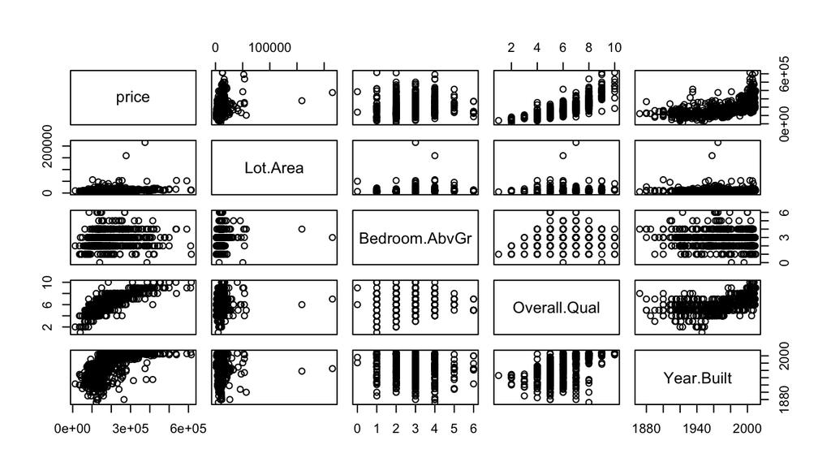

```r
# type your code for Question 4 here, and Knit
pairs(~price+Lot.Area+Bedroom.AbvGr+Overall.Qual+Year.Built, data=ames_train_transf)
```

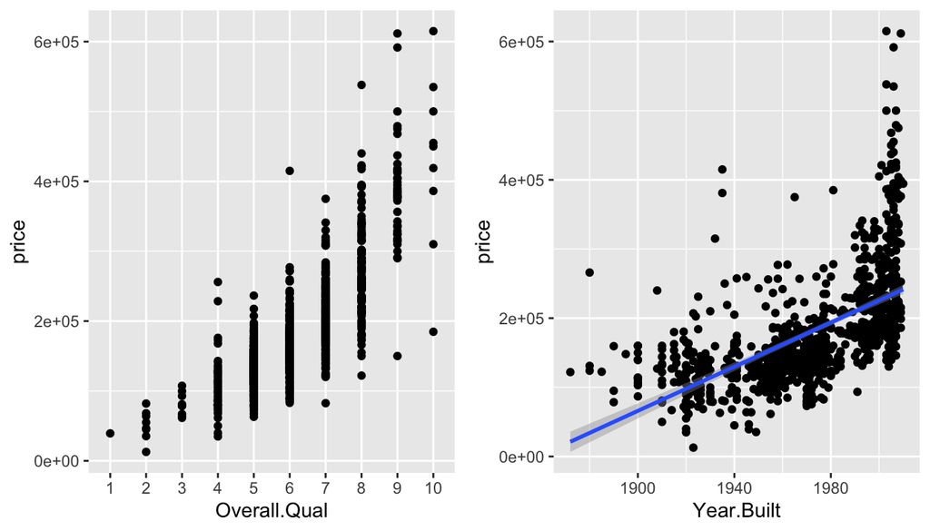

```r
overall_qual <- ggplot(ames_train_transf, aes(x=Overall.Qual, y=price)) + geom_point() + geom_smooth(method=lm)
year_built <- ggplot(ames_train_transf, aes(x=Year.Built, y=price)) + geom_point() + geom_smooth(method=lm)

grid.arrange(overall_qual, year_built, nrow=1)
```

5. Suppose you are examining the relationship between `price` and `area`. Which of the following variable transformations makes the relationship appear to be the most linear?
   1. Do not transform either `price` or `area`
   2. Log-transform `price` but not `area`
   3. Log-transform `area` but not `price`
   4. Log-transform both `price` and `area`

**Answer**: 4. Log-transform both `price` and `area`

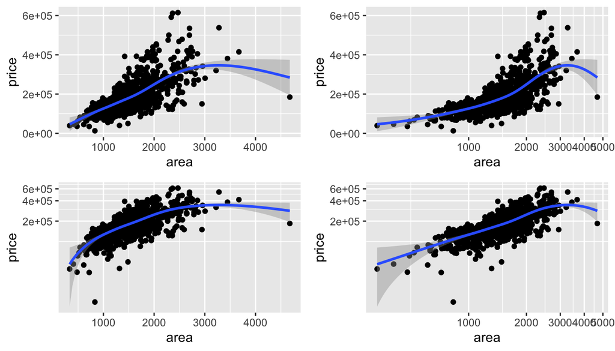

```r
# type your code for Question 5 here, and Knit
p1 <- ggplot(ames_train_transf, aes(x=area, y=price)) + geom_point() +  geom_smooth()
p2 <- ggplot(ames_train_transf, aes(x=area, y=price)) + geom_point() +  geom_smooth() + coord_trans(x='log10')
p3 <- ggplot(ames_train_transf, aes(x=area, y=price)) + geom_point() +  geom_smooth() + coord_trans(y='log10')
p4 <- ggplot(ames_train_transf, aes(x=area, y=price)) + geom_point() +  geom_smooth() + coord_trans(x='log10', y='log10')

grid.arrange(p1, p2, p3, p4, nrow = 2)
```

6. Suppose that your prior for the proportion of houses that have at least one garage is Beta(9, 1). What is your posterior? Assume a beta-binomial model for this proportion.
   1. Beta(954, 46)
   2. Beta(963, 46)
   3. Beta(954, 47)
   4. Beta(963, 47)

**Answer**: 4. Beta(963, 47) *(954,47 was incorrect)*

The amount of houses with at least space for 1 car = 953, hence, x = 953, n=1000 since it’s the dataframe size. However given the answers x=954

```r
# type your code for Question 6 here, and Knit
dim(ames_train_transf %>% filter(Garage.Cars >= 1))
```

```
## [1] 953  81
```

7. Which of the following statements is true about the dataset?
   1. Over 30 percent of houses were built after the year 1999. F
   2. The median housing price is greater than the mean housing price. F
   3. 21 houses do not have a basement. T
   4. 4 houses are located on gravel streets. F

**Answer**: 3. 21 houses do not have a basement

```r
# type your code for Question 7 here, and Knit
dim(ames_train_transf %>% filter(Year.Built > 1999))
```

```
## [1] 272  81
```

Only 272/1000 = 0.272, hence less than 30% were built after 1999.

```r
summary(
  select(ames_train_transf, c('Year.Built', 'price', 'Bsmt.Qual', 'Street'))
)
```

```
##    Year.Built       price        Bsmt.Qual   Street
##  Min.   :1872   Min.   : 12789       :  1   Grvl:  3
##  1st Qu.:1955   1st Qu.:129762   Ex  : 87   Pave:997
##  Median :1975   Median :159467   Fa  : 28
##  Mean   :1972   Mean   :181190   Gd  :424
##  3rd Qu.:2001   3rd Qu.:213000   Po  :  1
##  Max.   :2010   Max.   :615000   TA  :438
##                                  NA's: 21
```

8. Test, at the $\alpha = 0.05$ level, whether homes with a garage have larger square footage than those without a garage.
   1. With a p-value near 0.000, we reject the null hypothesis of no difference.
   2. With a p-value of approximately 0.032, we reject the null hypothesis of no difference.
   3. With a p-value of approximately 0.135, we fail to reject the null hypothesis of no difference.
   4. With a p-value of approximately 0.343, we fail to reject the null hypothesis of no difference.

**Answer**: 1. With a p-value near 0.000, we reject the null hypothesis of no difference.

```r
# type your code for Question 8 here, and Knit

area_and_garage <- ames_train_transf %>%
  select(area, Garage.Type) %>%
  mutate(Garage.Type = ifelse(!is.na(Garage.Type), "Has Garage", "No Garage" ))


inference(y = area, x = Garage.Type, data = area_and_garage, statistic = "mean", type = "ht", null = 0,
          alternative = "twosided", method = "theoretical")
```

```
## Response variable: numerical
## Explanatory variable: categorical (2 levels)
## n_Has Garage = 954, y_bar_Has Garage = 1492.6027, s_Has Garage = 502.5917
## n_No Garage = 46, y_bar_No Garage = 1145.0435, s_No Garage = 445.1805
## H0: mu_Has Garage =  mu_No Garage
## HA: mu_Has Garage != mu_No Garage
## t = 5.1395, df = 45
## p_value = < 0.0001
```

[figure not shown]

9. For homes with square footage greater than 2000, assume that the number of bedrooms above ground follows a Poisson distribution with rate $\lambda$. Your prior on $\lambda$ follows a Gamma distribution with mean 3 and standard deviation 1. What is your posterior mean and standard deviation for the average number of bedrooms in houses with square footage greater than 2000 square feet?
   1. Mean: 3.61, SD: 0.11
   2. Mean: 3.62, SD: 0.16
   3. Mean: 3.63, SD: 0.09
   4. Mean: 3.63, SD: 0.91

**Answer**: 3.Mean: 3.63, SD: 0.09 *Mean: 3.63, SD: 0.91 was incorrect)*

```r
# type your code for Question 9 here, and Knit
grt_2000 <- ames_train_transf %>% filter(area > 2000)
grt_2000 %>% summarise(sdev = sd(Bedroom.AbvGr), mean = mean(Bedroom.AbvGr))
```

```
##        sdev     mean
## 1 0.8719145 3.630435
```

```r
x_i = dim(grt_2000)[1]
n = dim(ames_train_transf)[1]
theta = 1/3
k = 9


k_post = (k + x_i)
theta_post = theta/(n*theta+1)

s_post = theta_post * ((k_post)**1/2)
mean_post = k_post*theta_post
print(s_post, mean_post)
```

```
## [1] 0
```

10. When regressing $\log$(`price`) on $\log$(`area`), there are some outliers. Which of the following do the three most outlying points have in common?
    1. They had abnormal sale conditions.
    2. They have only two bedrooms.
    3. They have an overall quality of less than 3.
    4. They were built before 1930.

**Answer**: 4. They were built before 1930

```r
# type your code for Question 10 here, and Knit
lin_model_ap <- ames_train_transf %>%
  mutate(log_price = log(price), log_area = log(area)) %>%
  select(c('log_price', 'log_area'))


summary(lin_model_ap)
```

```
##    log_price         log_area
##  Min.   : 9.456   Min.   :5.811
##  1st Qu.:11.773   1st Qu.:6.996
##  Median :11.980   Median :7.252
##  Mean   :12.018   Mean   :7.241
##  3rd Qu.:12.269   3rd Qu.:7.464
##  Max.   :13.329   Max.   :8.450
```

Let’s now make a linear regression and find the residuals to identify the outliers

```r
m1 <- lm(log_price ~ log_area, data=lin_model_ap)
summary(m1)
```

```
##
## Call:
## lm(formula = log_price ~ log_area, data = lin_model_ap)
##
## Residuals:
##      Min       1Q   Median       3Q      Max
## -2.08526 -0.14145  0.02048  0.17002  0.84536
##
## Coefficients:
##             Estimate Std. Error t value Pr(>|t|)
## (Intercept)  5.34441    0.19262   27.75   <2e-16 ***
## log_area     0.92167    0.02657   34.69   <2e-16 ***
## ---
## Signif. codes:  0 '***' 0.001 '**' 0.01 '*' 0.05 '.' 0.1 ' ' 1
##
## Residual standard error: 0.2834 on 998 degrees of freedom
## Multiple R-squared:  0.5466, Adjusted R-squared:  0.5461
## F-statistic:  1203 on 1 and 998 DF,  p-value: < 2.2e-16
```

Let’s take a look to the residuals

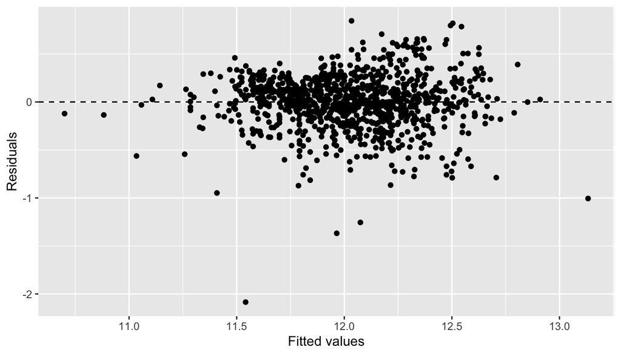

```r
ggplot(data = m1, aes(x = .fitted, y = .resid)) +
  geom_point() +
  geom_hline(yintercept = 0, linetype = "dashed") +
  xlab("Fitted values") +
  ylab("Residuals")
```

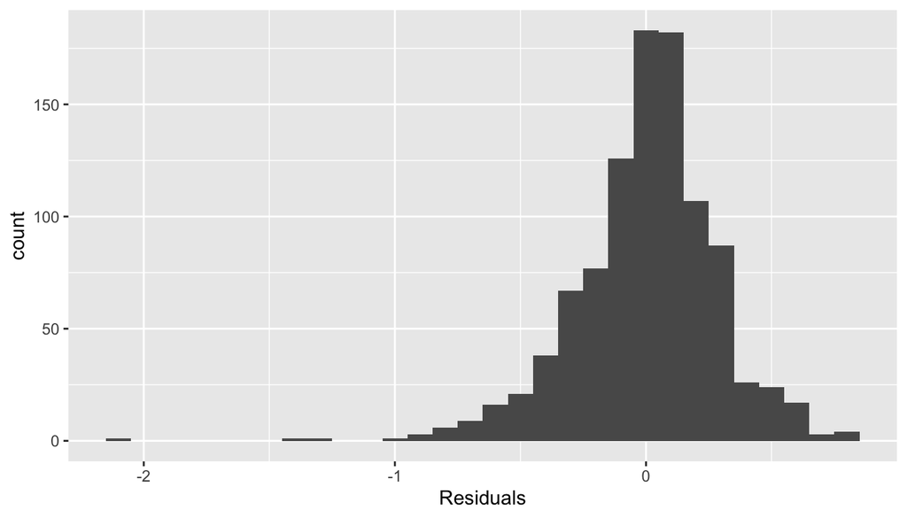

```r
ggplot(data = m1, aes(x = .resid)) +
  geom_histogram(binwidth = .1) +
  xlab("Residuals")
```

```r
outliers <- which(m1$residuals < -1.1)
print(outliers)
```

```
## 206 428 741
## 206 428 741
```

```r
outliers_simil <- ames_train_transf %>%
  select(c('price', 'area', 'Bedroom.AbvGr', 'Overall.Qual', 'Year.Built'))
outliers_simil[outliers,]
```

```
##     price area Bedroom.AbvGr Overall.Qual Year.Built
## 206 50000 1484             3            4       1910
## 428 12789  832             2            2       1923
## 741 40000 1317             3            4       1920
```

11. Which of the following are reasons to log-transform `price` if used as a dependent variable in a linear regression?
    1. `price` is right-skewed.
    2. `price` cannot take on negative values.
    3. `price` can only take on integer values.
    4. Both a and b.

**Answer**: 1. `price` is right-skewed. *4. Both a and b. was (incorrect)*

```r
# type your code for Question 11 here, and Knit
```

12. How many neighborhoods consist of only single-family homes? (e.g. `Bldg.Type` = `1Fam`)
    1. 0
    2. 1
    3. 2
    4. 3

**Answer**: 4. 3 neighborhoods

```r
# type your code for Question 12 here, and Knit
# single_family

bldg_type_neighborhood <- ames_train_transf %>% # [(ames_train_transf$Bldg.Type == '1Fam'),] %>%
  group_by(Neighborhood) %>%
  summarise(mean = mean(Bldg.Type == "1Fam")) # %>%


head(bldg_type_neighborhood[order(-bldg_type_neighborhood$mean),], 10)
```

```
## # A tibble: 10 × 2
##    Neighborhood  mean
##    <fct>        <dbl>
##  1 ClearCr      1
##  2 NoRidge      1
##  3 Timber       1
##  4 Gilbert      0.980
##  5 BrkSide      0.976
##  6 NWAmes       0.976
##  7 CollgCr      0.965
##  8 IDOTRR       0.943
##  9 NAmes        0.923
## 10 Sawyer       0.918
```

13. Using color, different plotting symbols, conditioning plots, etc., does there appear to be an association between $\log$(`area`) and the number of bedrooms above ground (`Bedroom.AbvGr`)?
    1. Yes
    2. No

**Answer**: 1. Yes

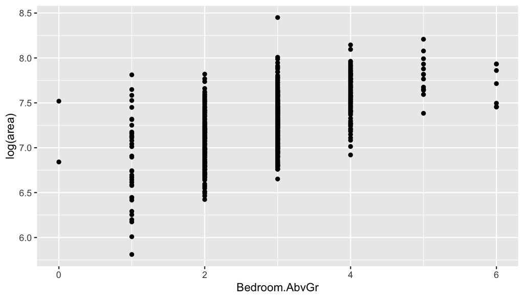

```r
# type your code for Question 13 here, and Knit
ggplot(ames_train_transf, aes(x=Bedroom.AbvGr, y=log(area))) + geom_point()
```

14. Of the people who have unfinished basements, what is the average square footage of the unfinished basement?
    1. 590.36
    2. 595.25
    3. 614.37
    4. 681.94

**Answer**: 2. 595.25

```r
# type your code for Question 14 here, and Knit
ames_train_transf %>%
  filter(Bsmt.Unf.SF != 0) %>%
  summarise(mean = mean(Bsmt.Unf.SF))
```

```
##       mean
## 1 595.2527
```